# Stat 202: Lecture 6 (covers pp. 84-99)

Nathan VanHoudnos  
10/6/2014

### Agenda

1. Prior checkpoints
2. Homework comments
3. Checkpoints #5 & #6 results
4. Lecture 6 (covers pp. 84-99)

### Passing scores on checkpoints

Passing is **somewhere around 60%** depending on

- the number of questions and
- the performance of the class.

Specifically:

- Checkpoint 1: 67% and above
- Checkpoint 2: 57% and above
- Checkpoint 3: 60% and above
- Checkpoint 4: 57% and above

### Crosstabs of passing / failing

`TRUE` is a pass, `FALSE` is a fail.  
`X1` is Checkpoint 1, `X2` Checkpoint 2, etc.

```r
                  X4 FALSE TRUE
X1    X2    X3
FALSE FALSE FALSE        2    0
            TRUE         0    2
      TRUE  FALSE        2    1
            TRUE         2    5
TRUE  FALSE FALSE        1    0
            TRUE         0    4
      TRUE  FALSE        1    1
            TRUE         2   53
```

### Agenda

1. Prior checkpoints
2. Homework comments
3. Checkpoints #5 & #6 results
4. Lecture 6 (covers pp. 84-99)

### Homework comments

- R Lesson Demo
- Questions?

### Agenda

1. Prior checkpoints
2. Homework comments
3. Checkpoints #5 & #6 results
4. Lecture 6 (covers pp. 84-99)

### Checkpoints #5 & #6

Checkpoint #5

- average score: 92% correct
- **sampling frame:** all individuals with a non-zero chance of being included, **NOT the sample**.
  - e.g. all students in statistics classes,
  - NOT the 500 students in the sample

Checkpoint #6

- average score: 94%
- every question answered correctly by least 85% of students

### Agenda

1. Prior checkpoints
2. Homework comments
3. Checkpoints #5 & #6 results
4. Lecture 6 (covers pp. 84-99)

### Big Picture

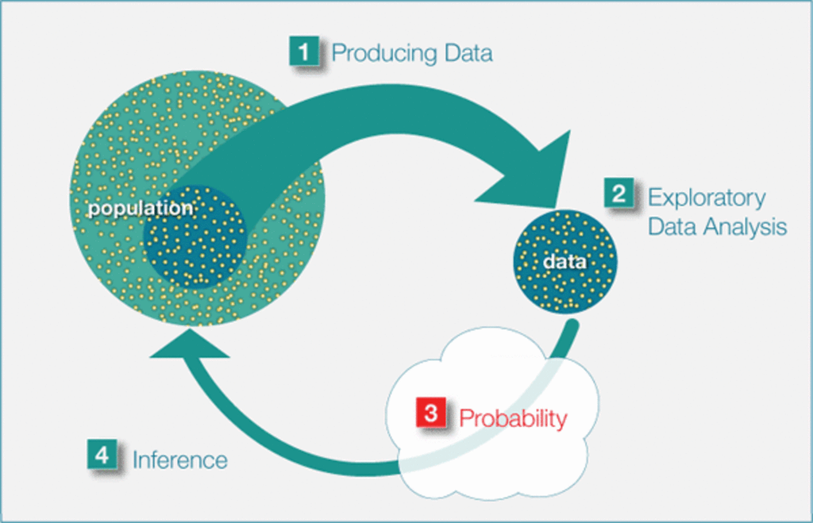

- This is where you begin to earn your formal studies requirement.

### Probability: Probably not intuitive

A game show

- Imagine you are a contestant at on a game show.
- In front of you, there are three doors (A, B, and C)
- One door has a prize behind it, the other two are empty.
- You pick door A
- The host, who knows which door the prize is behind, picks one of the empty doors and shows you it is empty.
- The host offers you the option to **stay** with door A or **switch** to the remaining door.
- **What should you do?**

### Intuition: Does not matter

Many people will answer, it does not matter.

- Something like: “Each door is equally likely, so you have a 50-50 chance either way.”
- **This is false.**

### Solution: Switch

Explanation by brute force.

|  | **Door A** | Door B | Door C |
| --- | --- | --- | --- |
| Case I | Prize | X | X |
| Case II | X | Prize | X |
| Case III | X | X | Prize |

### Solution: Switch

Explanation by brute force:

|  | **Door A** | Door B | Door C | Stay? | Switch? |
| --- | --- | --- | --- | --- | --- |
| Case I | Prize | X | X | Win | Lose |
| Case II | X | Prize | X | Lose | Win |
| Case III | X | X | Prize | Lose | Win |

If you **stay** you win 1/3 of the time.

If you **switch** you win 2/3 of the time.

### Solution: Switch

Explanation by simplification

Consider a reformulation of the game:

- The host asks you to pick either one door or **two** doors.
- one door: 1/3 chance of winning
- two doors: 2/3 chance of winning

The **switch strategy** in the original game is equivalent to **picking two** doors in the reformulated game.

### Solving probability problems

Broadly three strategies:

- **intuition:** usually fails
- **brute force:** always works, can be tedious
- **simplification:** beautiful and simple, but often requires hard-fought insight

The Statistics 202 probability unit will:

- teach **probability rules** and **brute force** strategies
- allow you to solve problems your way

### Probability Notation

Let \( A \) be some event.

Let \( P(A) \) be the probability that event \( A \) occurs.

- \( 0 \le P(A) \le 1 \) : the probability of any event is between zero and 1.

### Flipping a Fair Coin

A coin is fair, if, when flipped, it has an equal probability of landing on heads or tails.

Let \( H \) be the event that the coin lands heads

Let \( T \) be the event that the coin lands tails

The probability of a coin landing on

- heads is \( P(H) \)
- on tails is \( P(T) \)

A fair coin has

- \( P(H) = P(T) = .5 \)

### Rolling a fair die

Let \( 1 \) be the event that a die lands on 1 when rolled, \( 2 \) for 2, and so on up to \( 6 \).

If the die is fair, what is

- \( P(1) \) = ?
- \( P(2) \) = ?
- \( P(6) \) = ?

\( P(1) = P(2) = \dots = P(6) = \frac{1}{6} \approx 0.167 \)

### Empirical v. Classical probability

The coin and die examples were **theoretical probability**.

**Empirical probability**

- How would we know if a coin was fair or not?
- Flip it many times and compare proportion of heads with the **theoretical** answer.
- See demos on p. 91

### Empirical Probability

\[ \text{Relative Frequence of } A = \frac{\text{# times } A \text{ occured}}{\text{# of repetitions }} \]

**The Law of Large Numbers (LLN)**

The relative frequency of Event A approaches the theoretical probability of Event A as the number of repetitions tends to infinity.

**Note:** The LLN is a basis for interpreting what probability means.

### What is probability of at least one head in two flips?

**Sample Space:** All possible outcomes

- \( S = \{ HH, HT, TH, TT\} \)

**Events:** : collections of outcomes in \( S \)

- “At least one head:” \( A = \{HH, HT, TH\} \)
- “No heads:” \( B = \{TT\} \)

**Probability:** size of event (\( |A| \)) divided by size of sample space \[ P(A) = \frac{ |A| }{|S|} \quad \quad \left( \text{e.g.} \quad P(A) = \frac{3}{4} \right) \]

### Board Problems

Toss a coin 3 times. What is the probability of getting at least one head?

- **Sample Space**
- **Events**
- **Probability**

### Board Problems

There are two job openings for a staff position at a certain college, and 4 equally qualified candidates for the job (Ann, Beth, Jim and Dan). For fairness, the human resources department decides to choose two of the four candidates at random.

What is the probability of choosing a man and a woman?

- **Sample Space**
- **Events**
- **Probability**

### Board Problems

There are two job openings for a staff position at a certain college, and 4 equally qualified candidates for the job (Ann, Beth, Jim and Dan). For fairness, the human resources department decides to choose two of the four candidates at random.

What is the probability of choosing at least one man?

- **Sample Space**
- **Events**
- **Probability**

### Board Problems

When an ordinary fair die is rolled once, what is the probability that the number rolled is even?

- **Sample Space**
- **Events**
- **Probability**

### Board Problems

When two ordinary fair dice are rolled once, what is the probability that the sum of the numbers is seven?

- **Sample Space**
- **Events**
- **Probability**

> Note: This is why the robber comes on a 7 in Settlers of Catan.

### Board Problems

- Five candidates—2 men and 3 women—all equally qualified
- Pick two at random
- Legal department says a hire is discriminatory if both candidates are the same gender.
- What is the probability of both hires being the same gender?
  - **Sample Space**
  - **Events**
  - **Probability**

### Summary

- Possible gotchas:
  - The sample space is not big enough.
  - An ordered sample space when it should be unordered.
  - An event is missing an outcome.